# EDA

## Year and Mileage

by Slate Lee

```r
library(ggplot2)
```

```r
bmw_data <- read.csv("bmw.csv", header = TRUE, sep = ",")
summary(bmw_data)
```

```
##     model                year          price        transmission
##  Length:10781       Min.   :1996   Min.   :  1200   Length:10781
##  Class :character   1st Qu.:2016   1st Qu.: 14950   Class :character
##  Mode  :character   Median :2017   Median : 20462   Mode  :character
##                     Mean   :2017   Mean   : 22733
##                     3rd Qu.:2019   3rd Qu.: 27940
##                     Max.   :2020   Max.   :123456
##     mileage         fuelType              tax             mpg
##  Min.   :     1   Length:10781       Min.   :  0.0   Min.   :  5.5
##  1st Qu.:  5529   Class :character   1st Qu.:135.0   1st Qu.: 45.6
##  Median : 18347   Mode  :character   Median :145.0   Median : 53.3
##  Mean   : 25497                      Mean   :131.7   Mean   : 56.4
##  3rd Qu.: 38206                      3rd Qu.:145.0   3rd Qu.: 62.8
##  Max.   :214000                      Max.   :580.0   Max.   :470.8
##    engineSize
##  Min.   :0.000
##  1st Qu.:2.000
##  Median :2.000
##  Mean   :2.168
##  3rd Qu.:2.000
##  Max.   :6.600
```

Notably, this data set has 10781 entries of cars from year 1996 - 2020 and with a mileage from 1 - 214000.

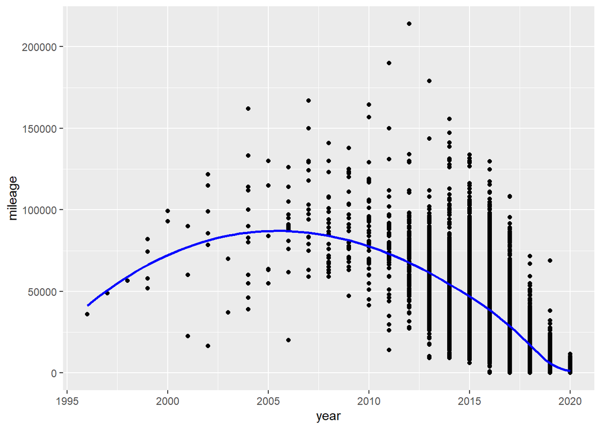

```r
ggplot(data = bmw_data, aes(x = year, y = mileage)) +
  geom_point() +
  geom_smooth(method = "loess", se = FALSE, color = "blue")
```

```r
correlation_coeff <- cor(bmw_data$year, bmw_data$mileage)
print(paste("Correlation:", round(correlation_coeff, 3)))
```

```
## [1] "Correlation: -0.774"
```

When correlation is calculated the resulting value is “-0.774,” again showing the expected negative relationship.

```r
mileage_counts <- sort(table(bmw_data$mileage), decreasing = TRUE)
head(mileage_counts, 100)
```

```
##
##   123    10   101  1000  5000  1501    11    12   100  1500   105   102   999
##   151   149    80    69    60    58    44    39    31    31    28    23    23
##  3000  6000     5  2000     9   103 45000    13  4000 30000  4500 20000 50000
##    23    23    22    21    20    20    20    19    18    18    17    17    17
##    15 23000 60000   500  5500 26000 40000 70000    99   110  3500 25000  2500
##    16    16    16    15    15    15    15    15    14    14    14    14    13
## 33000 43000 56000 59000 76000     6  5656 32000 35000 63000    14  7000  8000
##    13    13    13    13    13    12    12    12    12    12    11    11    11
## 18000 38000 39000 42000 44000 46000 62000 65000 67000    16 28000 29000 31000
##    11    11    11    11    11    11    11    11    11    10    10    10    10
## 36000 37000 51000 68000 90000  6500 17000 47000 48000 57000 75000 80000   151
##    10    10    10    10    10     9     9     9     9     9     9     9     8
##  1550 10000 22000 24000 27000 41000 82000 92000   150  9000 13000 16000 34000
##     8     8     8     8     8     8     8     8     7     7     7     7     7
## 52000 53000 64000 81000 83000 84000 85000 89000     8
##     7     7     7     7     7     7     7     7     6
```

The above table counts the amount of times any given mileage value occurs, and has them ordered from highest to lowest. Many of the most common mileage values are rounded to the nearest hundred or thousand (e.g. “1000”, “5000”, “100”). This shows that the original data set has been rounded, and are not the sort of random values which we would expect. The table does show a mode of 123 which occurred 151 times. This is a strangely specific value especially given that the surrounding numbers 122 and 124 do not show up on the top 100 values. This is evidence that the may not accurately correspond to real world data, or has been adjusted.

## Fuel Type

by Shaye Shankar

```r
library(ggplot2)
```

```r
df <- read.csv("bmw.csv")
summary(df)
```

```
##     model                year          price        transmission
##  Length:10781       Min.   :1996   Min.   :  1200   Length:10781
##  Class :character   1st Qu.:2016   1st Qu.: 14950   Class :character
##  Mode  :character   Median :2017   Median : 20462   Mode  :character
##                     Mean   :2017   Mean   : 22733
##                     3rd Qu.:2019   3rd Qu.: 27940
##                     Max.   :2020   Max.   :123456
##     mileage         fuelType              tax             mpg
##  Min.   :     1   Length:10781       Min.   :  0.0   Min.   :  5.5
##  1st Qu.:  5529   Class :character   1st Qu.:135.0   1st Qu.: 45.6
##  Median : 18347   Mode  :character   Median :145.0   Median : 53.3
##  Mean   : 25497                      Mean   :131.7   Mean   : 56.4
##  3rd Qu.: 38206                      3rd Qu.:145.0   3rd Qu.: 62.8
##  Max.   :214000                      Max.   :580.0   Max.   :470.8
##    engineSize
##  Min.   :0.000
##  1st Qu.:2.000
##  Median :2.000
##  Mean   :2.168
##  3rd Qu.:2.000
##  Max.   :6.600
```

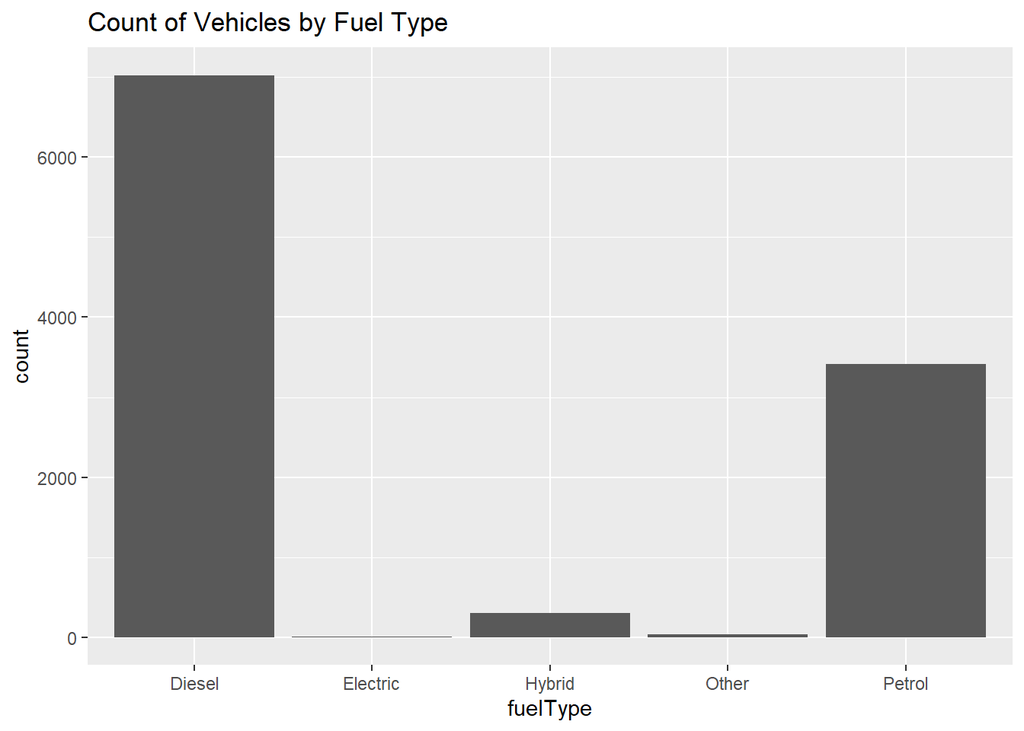

```r
ggplot(df, aes(x=fuelType)) +
  geom_bar() +
  labs(title="Count of Vehicles by Fuel Type")
```

```r
fuel_counts_base <- table(df$fuelType)
print(fuel_counts_base)
```

```
##
##   Diesel Electric   Hybrid    Other   Petrol
##     7027        3      298       36     3417
```

There’s the most numerical and consistent data on petrol cars and diesel cars. There’s only 3 instances for electric cars. The 36 “other” fuelType category may be the result of missing data of other cars.

## MPG

by Shaye Shankar

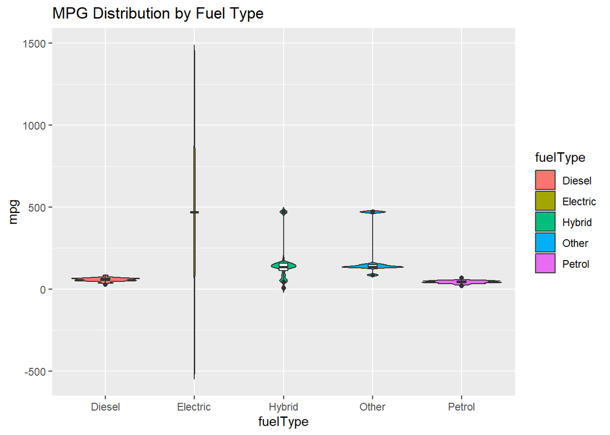

```r
ggplot(df, aes(x=fuelType, y=mpg, fill=fuelType)) +
  geom_violin(trim=FALSE) +
  geom_boxplot(width=0.1, fill="white") +
  labs(title="MPG Distribution by Fuel Type")
```

Petrol and Diesel cars are the only real trustworthy information for looking at miles and the data makes seems real as diesel, on average, has just slightly more mpg than petrol. Electric has the highest range and likely should not be included on this plot, since it is an electric car and does not have a real mileage per gallon. There are a lot of inconsistencies with MPG for Hybrids, with among the highest being 470 miles per gallon, which is very likely an error.

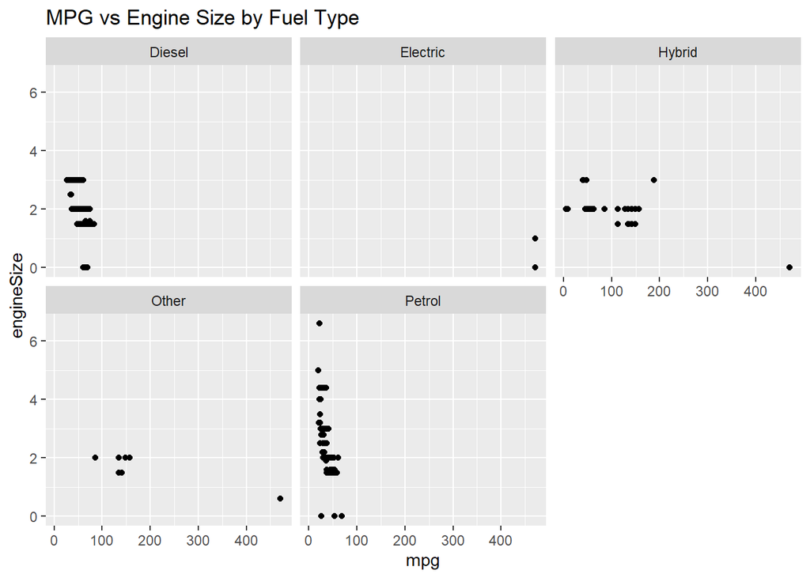

```r
ggplot(df, aes(x=mpg, y=engineSize)) +
  geom_point() +
  facet_wrap(~ fuelType) +
  labs(title="MPG vs Engine Size by Fuel Type")
```

Electric vehicles do not have an engine size, and thus should not be included in the comparison.There appears to be a weaker correlation between engine size and mpg for hybrids and a massive outlier with 400+ mpg. Diesel and petrol have the most consistent data, following a trend of having higher miles per gallon the smaller the engine size is, unless the engine size is 0 in which case the data is incorrect as this should be impossible.

## Tax

by AJ Wood

```
##     model                year          price        transmission
##  Length:10781       Min.   :1996   Min.   :  1200   Length:10781
##  Class :character   1st Qu.:2016   1st Qu.: 14950   Class :character
##  Mode  :character   Median :2017   Median : 20462   Mode  :character
##                     Mean   :2017   Mean   : 22733
##                     3rd Qu.:2019   3rd Qu.: 27940
##                     Max.   :2020   Max.   :123456
##     mileage         fuelType              tax             mpg
##  Min.   :     1   Length:10781       Min.   :  0.0   Min.   :  5.5
##  1st Qu.:  5529   Class :character   1st Qu.:135.0   1st Qu.: 45.6
##  Median : 18347   Mode  :character   Median :145.0   Median : 53.3
##  Mean   : 25497                      Mean   :131.7   Mean   : 56.4
##  3rd Qu.: 38206                      3rd Qu.:145.0   3rd Qu.: 62.8
##  Max.   :214000                      Max.   :580.0   Max.   :470.8
##    engineSize
##  Min.   :0.000
##  1st Qu.:2.000
##  Median :2.000
##  Mean   :2.168
##  3rd Qu.:2.000
##  Max.   :6.600
```

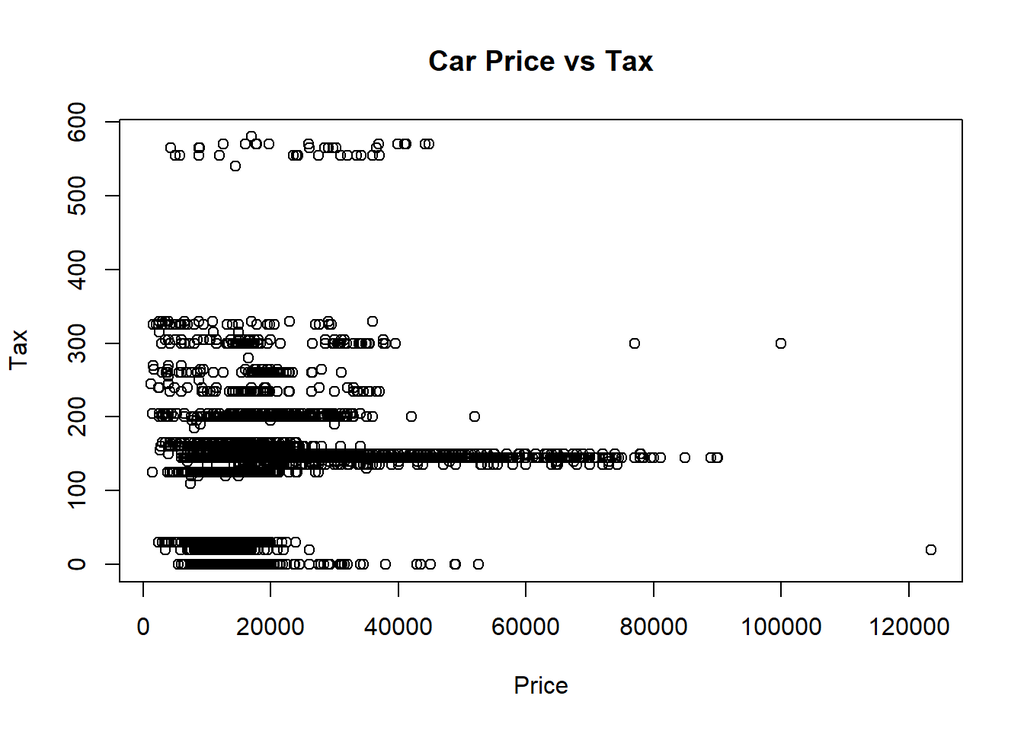

[figure not shown]

```
## Call:
## rpart(formula = tax ~ price, data = car_data)
##   n= 10781
##
##           CP nsplit rel error    xerror       xstd
## 1 0.16401721      0 1.0000000 1.0003345 0.03232221
## 2 0.03504082      1 0.8359828 0.8391585 0.03209337
## 3 0.01157827      2 0.8009420 0.8084215 0.03075885
## 4 0.01000000      3 0.7893637 0.7995748 0.03083590
##
## Variable importance
## price
##   100
##
## Node number 1: 10781 observations,    complexity param=0.1640172
##   mean=131.7021, MSE=3783.222
##   left son=2 (3406 obs) right son=3 (7375 obs)
##   Primary splits:
##       price < 16201   to the left,  improve=0.1640172, (0 missing)
##
## Node number 2: 3406 observations,    complexity param=0.03504082
##   mean=95.04698, MSE=5976.48
##   left son=4 (3288 obs) right son=5 (118 obs)
##   Primary splits:
##       price < 5999.5  to the right, improve=0.07021098, (0 missing)
##
## Node number 3: 7375 observations
##   mean=148.6305, MSE=1863.223
##
## Node number 4: 3288 observations,    complexity param=0.01157827
##   mean=91.16636, MSE=5280.369
##   left son=8 (2173 obs) right son=9 (1115 obs)
##   Primary splits:
##       price < 13998.5 to the left,  improve=0.02719998, (0 missing)
##
## Node number 5: 118 observations
##   mean=203.178, MSE=13261.3
##
## Node number 8: 2173 observations
##   mean=82.58168, MSE=5255.507
##
## Node number 9: 1115 observations
##   mean=107.8969, MSE=4905.285
```

```r
summary(car_data$tax)
```

```
##    Min. 1st Qu.  Median    Mean 3rd Qu.    Max.
##     0.0   135.0   145.0   131.7   145.0   580.0
```

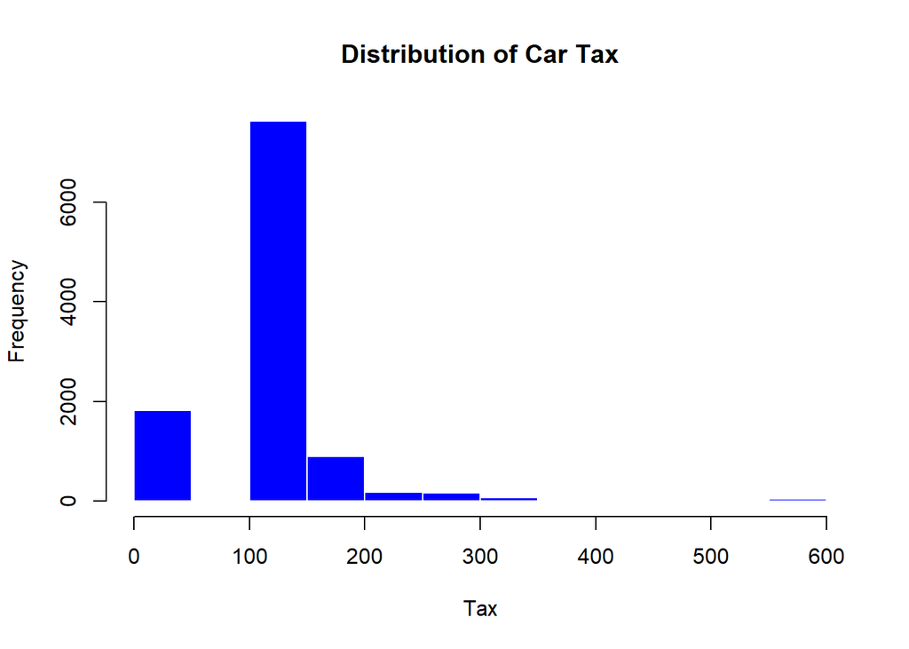

```r
hist(car_data$tax, main = "Distribution of Car Tax", xlab = "Tax", col = "blue",border = "white")
```

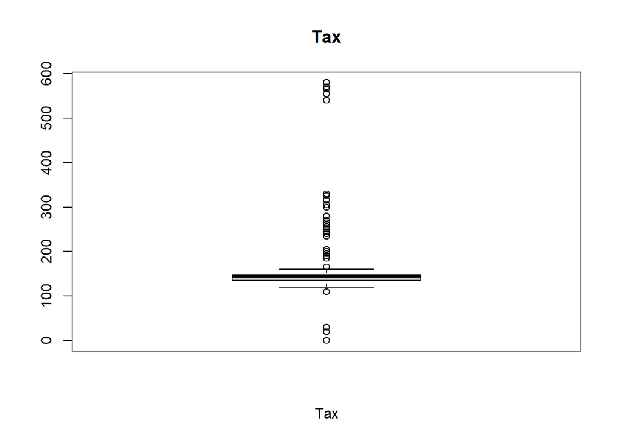

```r
boxplot(car_data$tax, data = car_data, main = "Tax", xlab = "Tax")
```

```r
carModel <- rpart(tax ~ fuelType, data = car_data)
summary(carModel)
```

```
## Call:
## rpart(formula = tax ~ fuelType, data = car_data)
##   n= 10781
##
##           CP nsplit rel error    xerror       xstd
## 1 0.10331785      0 1.0000000 1.0001811 0.03231542
## 2 0.01357799      1 0.8966822 0.8972703 0.02780175
## 3 0.01000000      2 0.8831042 0.8839014 0.02768840
##
## Variable importance
## fuelType
##      100
##
## Node number 1: 10781 observations,    complexity param=0.1033178
##   mean=131.7021, MSE=3783.222
##   left son=2 (7364 obs) right son=3 (3417 obs)
##   Primary splits:
##       fuelType splits as  LLLLR, improve=0.1033178, (0 missing)
##
## Node number 2: 7364 observations,    complexity param=0.01357799
##   mean=118.2347, MSE=3358.433
##   left son=4 (337 obs) right son=5 (7027 obs)
##   Primary splits:
##       fuelType splits as  RLLL-, improve=0.02239266, (0 missing)
##
## Node number 3: 3417 observations
##   mean=160.7258, MSE=3465.438
##
## Node number 4: 337 observations
##   mean=78.63501, MSE=4755.704
##
## Node number 5: 7027 observations
##   mean=120.1338, MSE=3212.612
```

## Price

by AJ Wood

```r
summary(car_data$price)
```

```
##    Min. 1st Qu.  Median    Mean 3rd Qu.    Max.
##    1200   14950   20462   22733   27940  123456
```

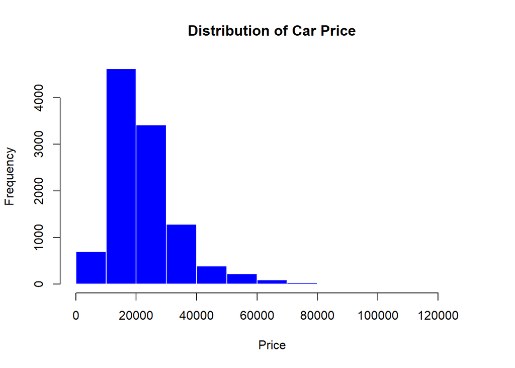

```r
hist(car_data$price, main = "Distribution of Car Price", xlab = "Price", col = "blue",border = "white")
```

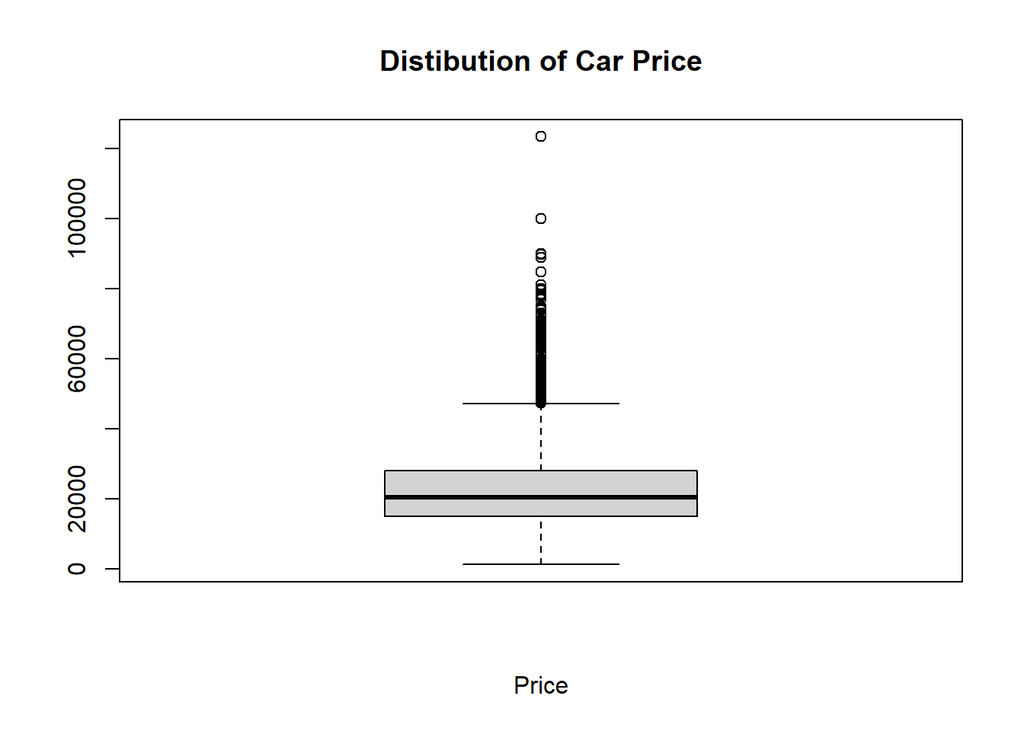

```r
boxplot(car_data$price, data = car_data, main = "Distibution of Car Price", xlab = "Price")
```

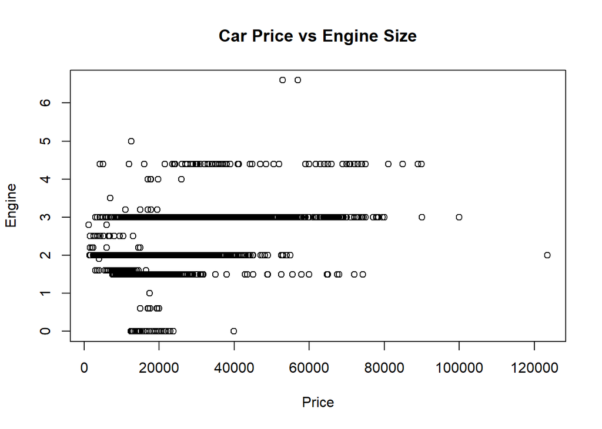

```r
plot(car_data$price, car_data$engineSize, main = "Car Price vs Engine Size", xlab="Price", ylab="Engine")
```

```r
carModel <- rpart(price ~ engineSize, data = car_data)
summary(carModel)
```

```
## Call:
## rpart(formula = price ~ engineSize, data = car_data)
##   n= 10781
##
##           CP nsplit rel error    xerror       xstd
## 1 0.20257854      0 1.0000000 1.0001628 0.02363204
## 2 0.01434538      1 0.7974215 0.7978128 0.01706760
## 3 0.01281539      2 0.7830761 0.7861732 0.01724470
## 4 0.01000000      3 0.7702607 0.7741029 0.01676534
##
## Variable importance
## engineSize
##        100
##
## Node number 1: 10781 observations,    complexity param=0.2025785
##   mean=22733.41, MSE=1.303022e+08
##   left son=2 (8229 obs) right son=3 (2552 obs)
##   Primary splits:
##       engineSize < 2.9  to the left,  improve=0.2025785, (0 missing)
##
## Node number 2: 8229 observations,    complexity param=0.01434538
##   mean=19872.27, MSE=6.36273e+07
##   left son=4 (1632 obs) right son=5 (6597 obs)
##   Primary splits:
##       engineSize < 1.95 to the left,  improve=0.03848862, (0 missing)
##
## Node number 3: 2552 observations,    complexity param=0.01281539
##   mean=31959.25, MSE=2.337849e+08
##   left son=6 (2470 obs) right son=7 (82 obs)
##   Primary splits:
##       engineSize < 4.2  to the left,  improve=0.03017487, (0 missing)
##
## Node number 4: 1632 observations
##   mean=16725.96, MSE=4.697886e+07
##
## Node number 5: 6597 observations
##   mean=20650.62, MSE=6.469112e+07
##
## Node number 6: 2470 observations
##   mean=31475.31, MSE=2.208219e+08
##
## Node number 7: 82 observations
##   mean=46536.39, MSE=4.047091e+08
```

//after running rpart it seems that the bigger the engine size, the higher the price with a split between 1.95, 2.9, and 4,2 liters. For engines < 1.95 avg price: 16,726 For engines 1.95-2.9 avg price: 20,651 For engines 2.9-4.2 avg prices: 31,475 For engines > 4.2 avg prices: 46,536